# Predictors of Red Wine Quality by Andrea Brown

# Introduction

# Exploratory Data Analysis

I’ll start by importing the data and looking at a summary of the variables.

```
##  fixed.acidity   volatile.acidity  citric.acid    residual.sugar
##  Min.   : 4.60   Min.   :0.1200   Min.   :0.000   Min.   : 0.900
##  1st Qu.: 7.10   1st Qu.:0.3900   1st Qu.:0.090   1st Qu.: 1.900
##  Median : 7.90   Median :0.5200   Median :0.260   Median : 2.200
##  Mean   : 8.32   Mean   :0.5278   Mean   :0.271   Mean   : 2.539
##  3rd Qu.: 9.20   3rd Qu.:0.6400   3rd Qu.:0.420   3rd Qu.: 2.600
##  Max.   :15.90   Max.   :1.5800   Max.   :1.000   Max.   :15.500
##    chlorides       free.sulfur.dioxide total.sulfur.dioxide
##  Min.   :0.01200   Min.   : 1.00       Min.   :  6.00
##  1st Qu.:0.07000   1st Qu.: 7.00       1st Qu.: 22.00
##  Median :0.07900   Median :14.00       Median : 38.00
##  Mean   :0.08747   Mean   :15.87       Mean   : 46.47
##  3rd Qu.:0.09000   3rd Qu.:21.00       3rd Qu.: 62.00
##  Max.   :0.61100   Max.   :72.00       Max.   :289.00
##     density             pH          sulphates         alcohol
##  Min.   :0.9901   Min.   :2.740   Min.   :0.3300   Min.   : 8.40
##  1st Qu.:0.9956   1st Qu.:3.210   1st Qu.:0.5500   1st Qu.: 9.50
##  Median :0.9968   Median :3.310   Median :0.6200   Median :10.20
##  Mean   :0.9967   Mean   :3.311   Mean   :0.6581   Mean   :10.42
##  3rd Qu.:0.9978   3rd Qu.:3.400   3rd Qu.:0.7300   3rd Qu.:11.10
##  Max.   :1.0037   Max.   :4.010   Max.   :2.0000   Max.   :14.90
##     quality
##  Min.   :3.000
##  1st Qu.:5.000
##  Median :6.000
##  Mean   :5.636
##  3rd Qu.:6.000
##  Max.   :8.000
```

### A Closer Look at Wine Quality

Next I take a look at the distribution of the wine quality variable. It looks like the integers are fairly normally distributed with the vast majority of integers being 5, 6, or 7.

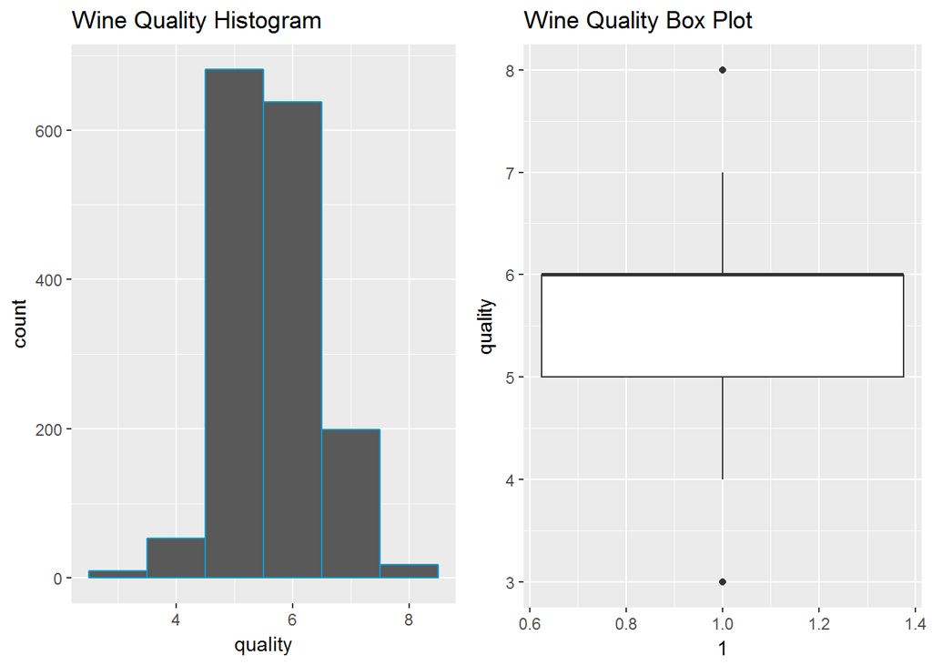

# Dependent Variable Analysis

One thing I observe from the summary of the data is that the minimum rating of the wines is a 3 and the maximum rating is an 8. Looking at the histogram, I notice the vast majority of the wine quality integers are 5, 6, or 7, which is concerning because there isn’t much variation in my outcome variable. I also notice that the wine quality integers 3 and 8 are outliers in my box plot.

Next I’ll take a closer look at the potential predictor variables and their distributions.

### Overview of Bivariate Relationships

```
##  [1] "fixed.acidity"        "volatile.acidity"     "citric.acid"
##  [4] "residual.sugar"       "chlorides"            "free.sulfur.dioxide"
##  [7] "total.sulfur.dioxide" "density"              "pH"
## [10] "sulphates"            "alcohol"              "quality"
```

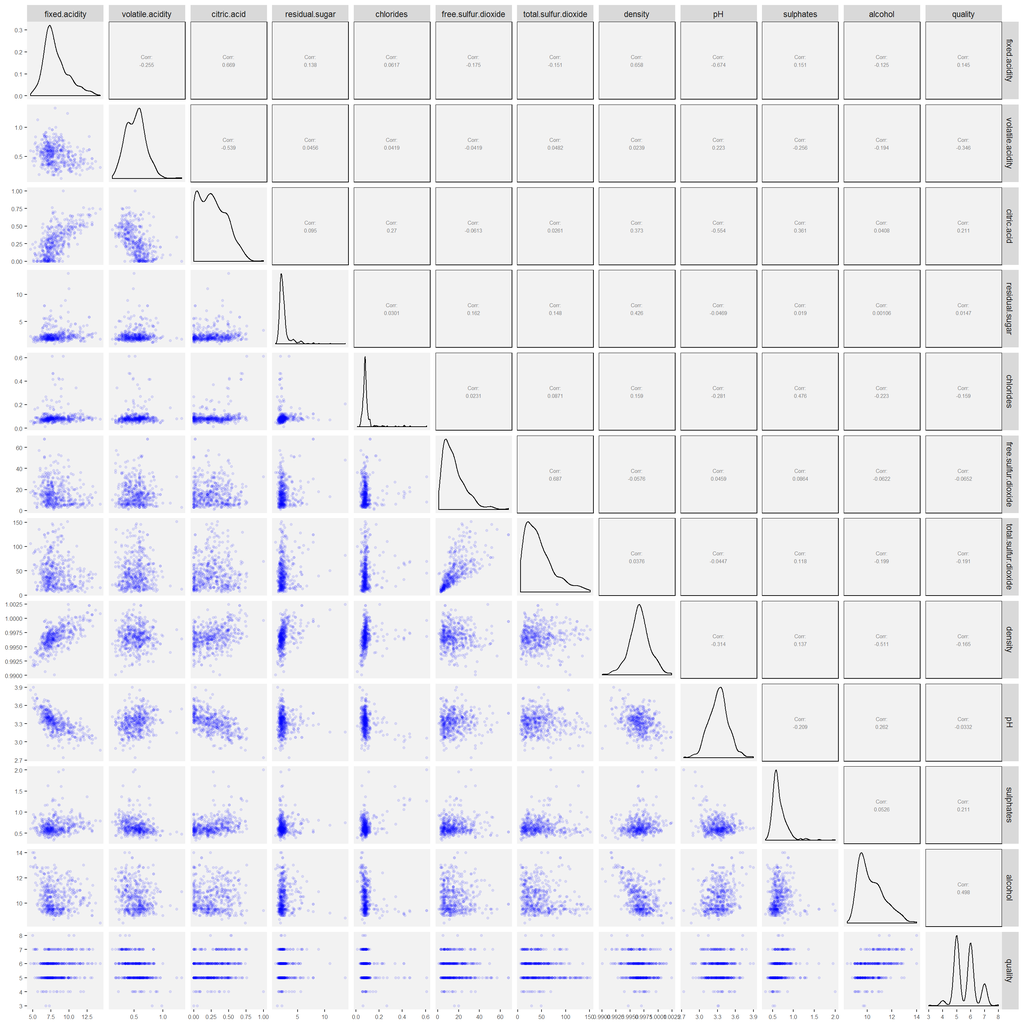

### Wine Quality vs. Fixed Acidity

The histogram of the fixed acidity looks fairly normal, so I won’t transform the data. I jittered the points in the scatterplot to compensate for the gaps due to the integer values for wine quality. A scatterplot of wine quality vs. fixed acidity does not reveal any significant trends and the correlation factor is not that high, so I won’t look further into fixed acidity.

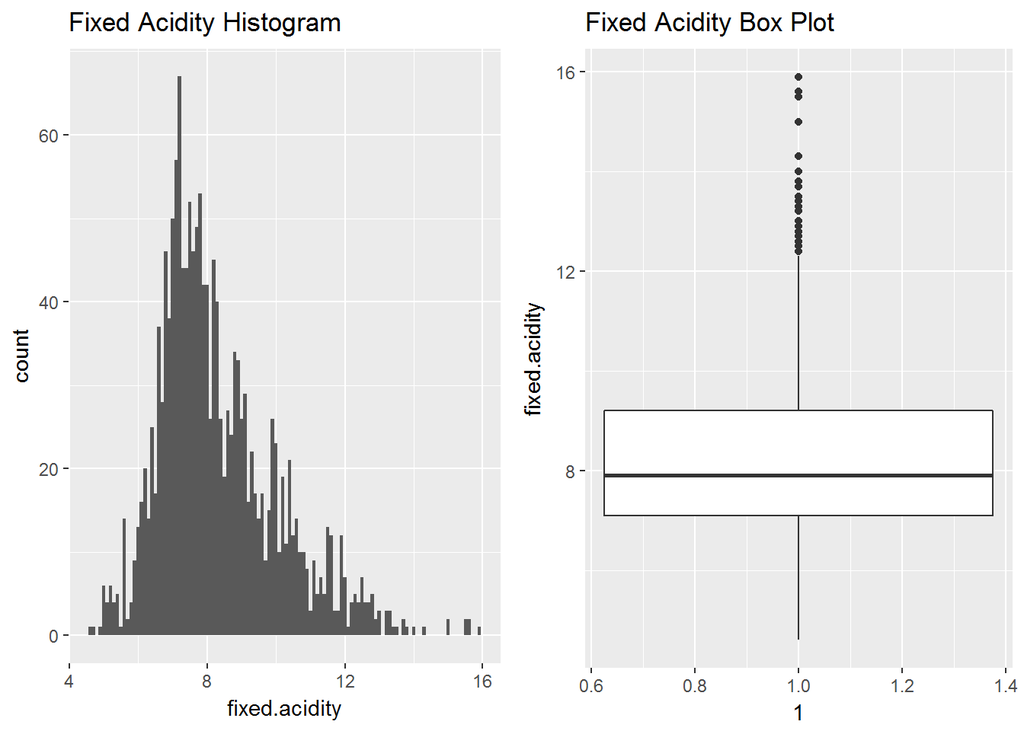

```
##
##  Pearson's product-moment correlation
##
## data:  wines$quality and wines$fixed.acidity
## t = 4.996, df = 1597, p-value = 6.496e-07
## alternative hypothesis: true correlation is not equal to 0
## 95 percent confidence interval:
##  0.07548957 0.17202667
## sample estimates:
##       cor
## 0.1240516
```

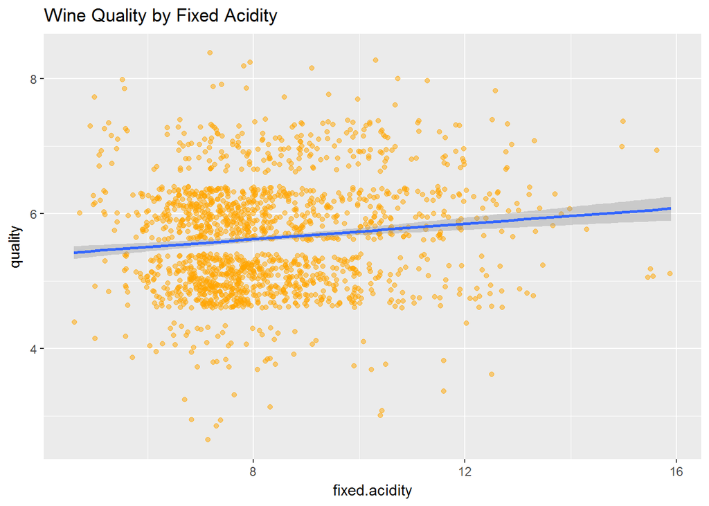

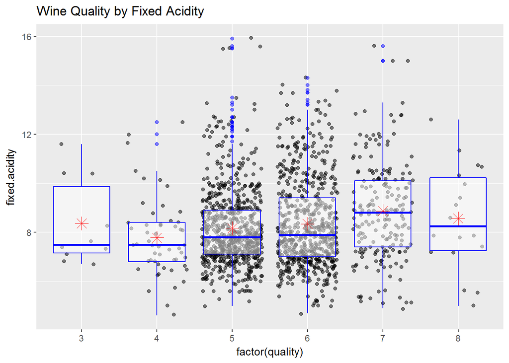

### Wine Quality vs. Volatile Acidity

The histogram of the volatile acidity looks almost lognormal, so I will try a log10 transformation on the x-axis. The log10 transformation of the x-axis improves the linearity of the scatterplot and there appears to be somewhat of a correlation although not a strong one. I remove the 1% highest and 1% lowest values of volatile acidity and this also helps the linearity of the scatter plot.

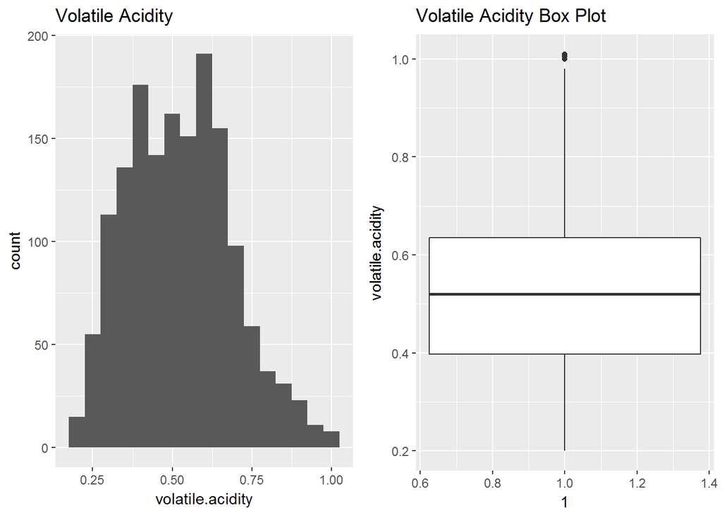

```
##
##  Pearson's product-moment correlation
##
## data:  wines_subset$quality and I(log10(wines_subset$volatile.acidity))
## t = -15.841, df = 1561, p-value < 2.2e-16
## alternative hypothesis: true correlation is not equal to 0
## 95 percent confidence interval:
##  -0.4140930 -0.3286327
## sample estimates:
##        cor
## -0.3721513
```

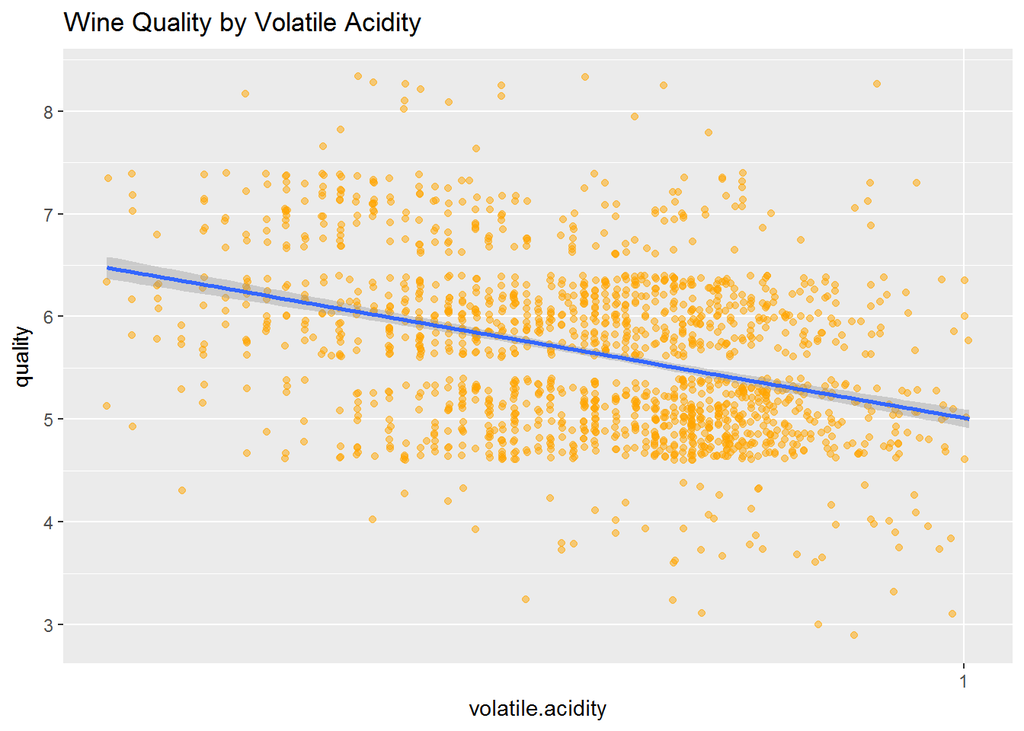

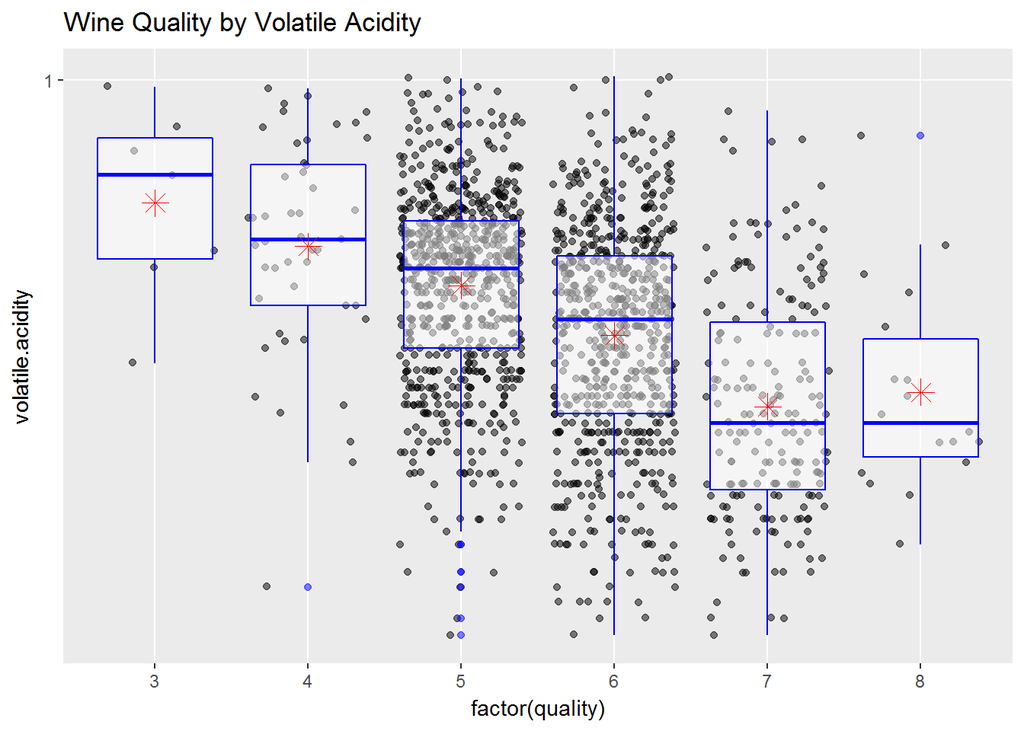

### Wine Quality vs. Citric Acid

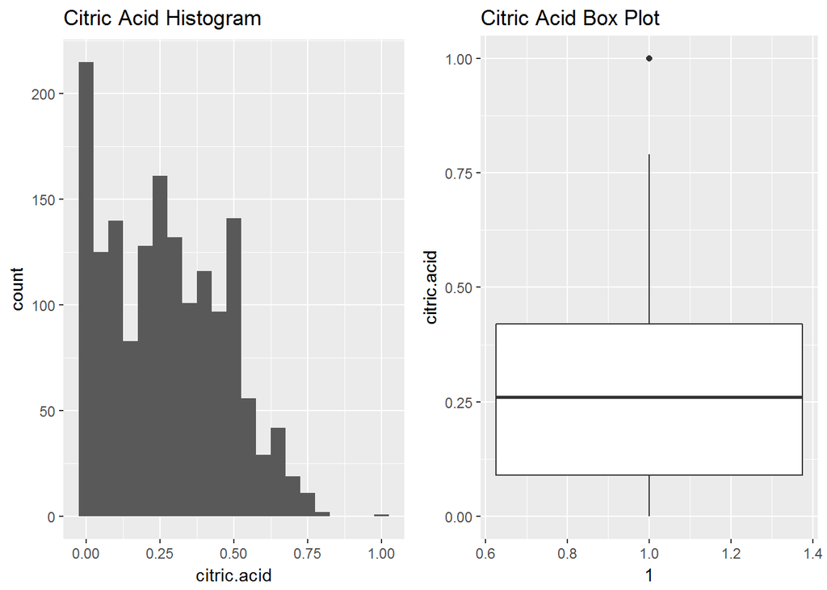

```
##
##  Pearson's product-moment correlation
##
## data:  wines$quality and I(sqrt(wines$citric.acid))
## t = 8.4418, df = 1597, p-value < 2.2e-16
## alternative hypothesis: true correlation is not equal to 0
## 95 percent confidence interval:
##  0.1592748 0.2531386
## sample estimates:
##       cor
## 0.2066822
```

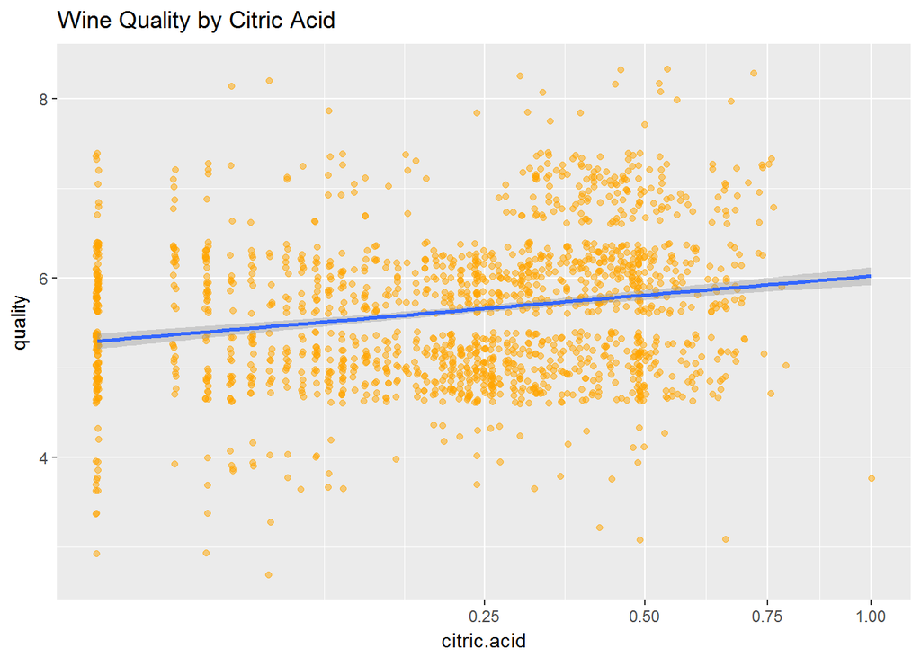

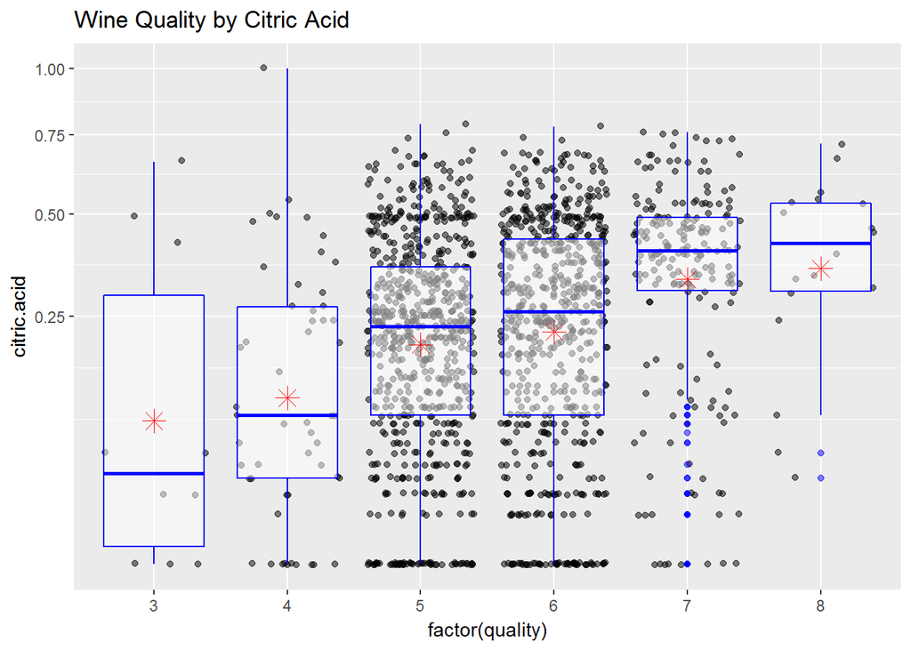

### Wine Quality vs. Residual Sugar

The histogram of the residual sugar looks skewed, so I’ll perform a lognormal transformation on the data. The correlation coefficient is fairly low and the scatterplot is not revealing any trends, so I will not pursue this variable further.

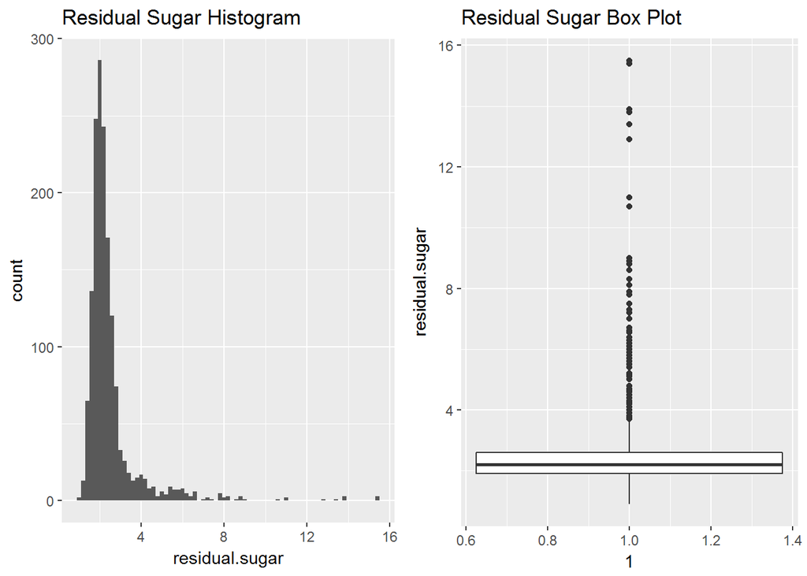

```
##
##  Pearson's product-moment correlation
##
## data:  wines$quality and log10(wines$residual.sugar)
## t = 0.94071, df = 1597, p-value = 0.347
## alternative hypothesis: true correlation is not equal to 0
## 95 percent confidence interval:
##  -0.02551727  0.07247084
## sample estimates:
##        cor
## 0.02353331
```

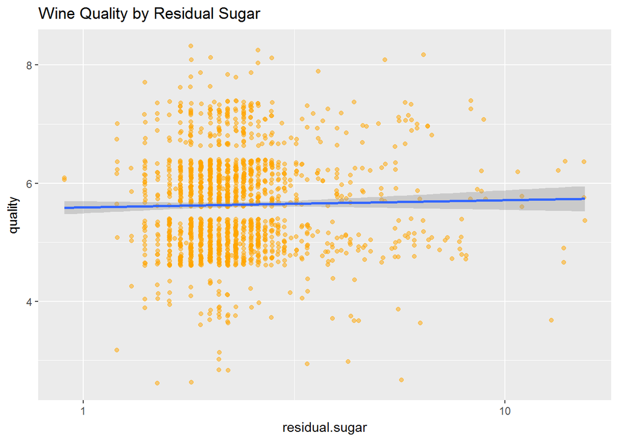

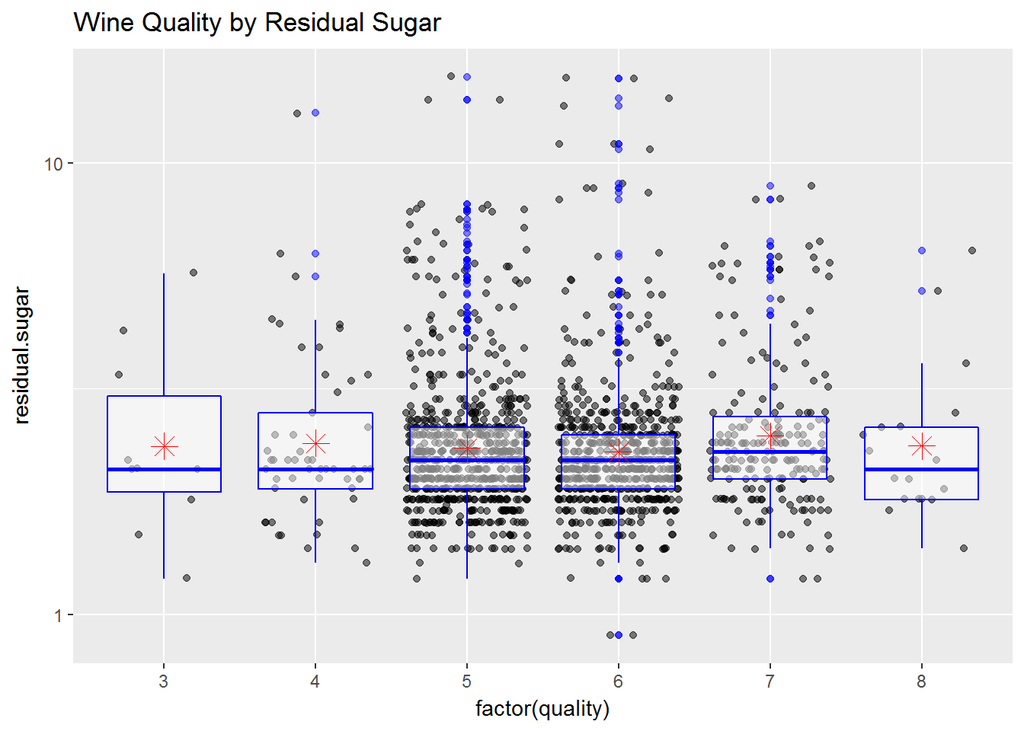

### Wine Quality vs. Chlorides

The histogram of the chlorides looks skewed, so I’ll perform a lognormal transformation on the data. The correlation coefficient is fairly low and the scatterplot is not revealing any trends, so I will not pursue this variable further.

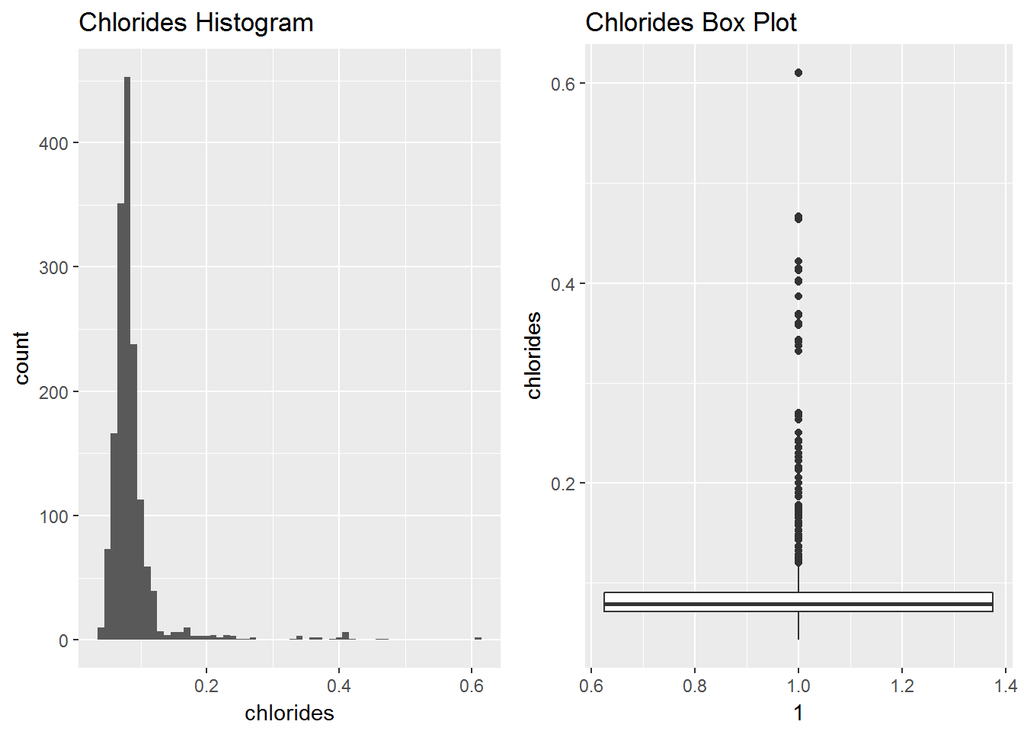

```
##
##  Pearson's product-moment correlation
##
## data:  subset_data$quality and log10(subset_data$chlorides)
## t = -6.5648, df = 1581, p-value = 7.045e-11
## alternative hypothesis: true correlation is not equal to 0
## 95 percent confidence interval:
##  -0.2104776 -0.1145495
## sample estimates:
##        cor
## -0.1628985
```

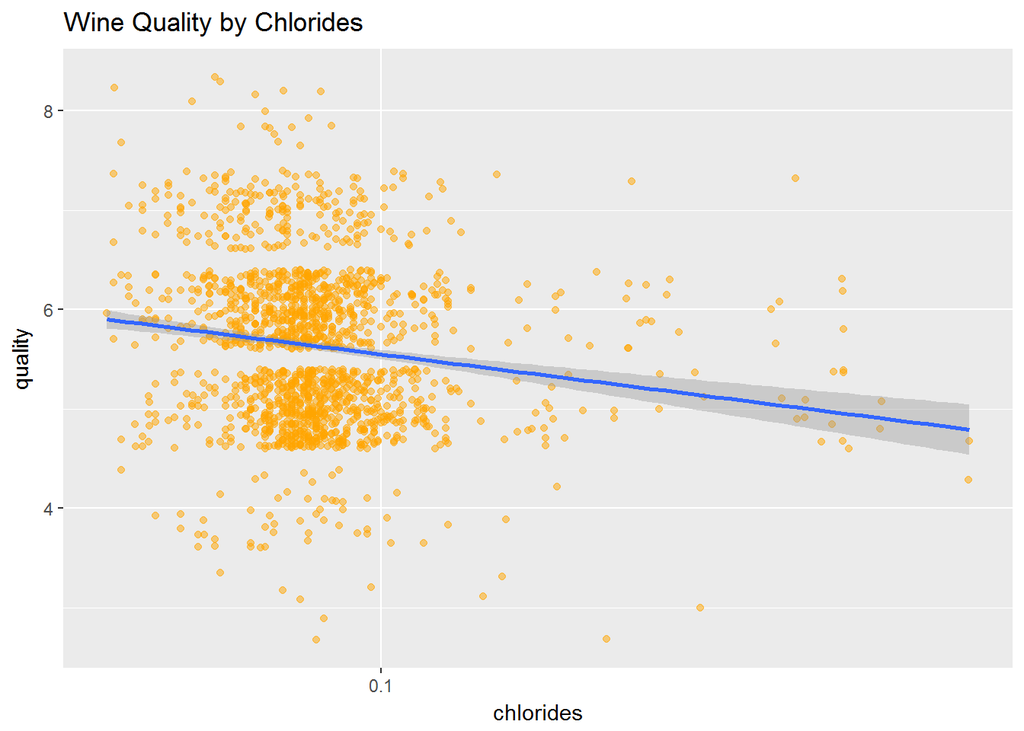

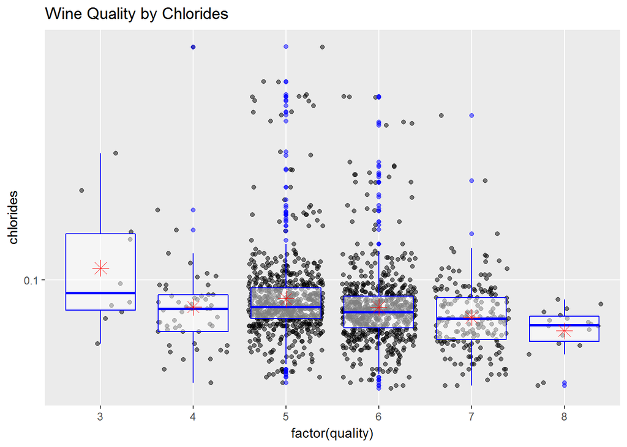

### Wine Quality vs. Free Sulfur Dioxide

The histogram of the free sulfur dioxide looks skewed, so I’ll perform a lognormal transformation on the data. The correlation coefficient is very low and the scatterplot is not revealing any trends, so I will not pursue this variable further.

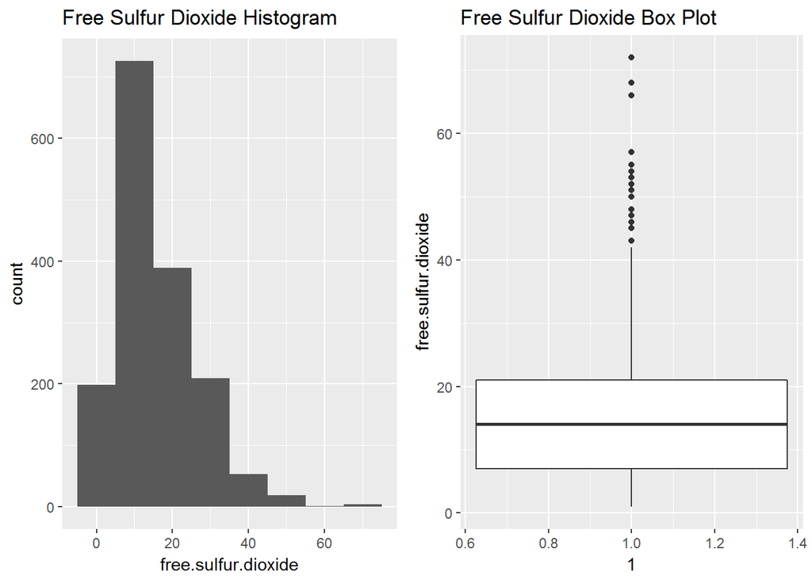

```
##
##  Pearson's product-moment correlation
##
## data:  wines$quality and log10(wines$free.sulfur.dioxide)
## t = -2.0041, df = 1597, p-value = 0.04522
## alternative hypothesis: true correlation is not equal to 0
## 95 percent confidence interval:
##  -0.098865884 -0.001068979
## sample estimates:
##         cor
## -0.05008749
```

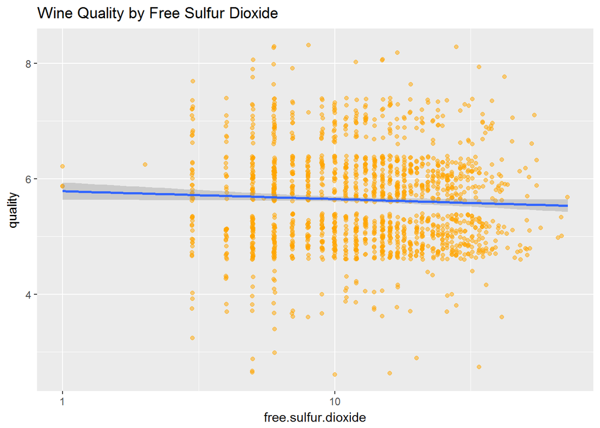

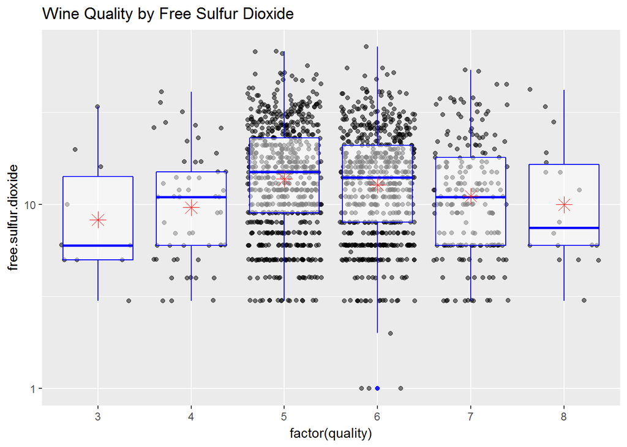

### Wine Quality vs. Total Sulfur Dioxide

The histogram of the total sulfur dioxide looks skewed, so I’ll perform a lognormal transformation on the data. The correlation coefficient is fairly low and the scatterplot is not revealing any trends, so I will not pursue this variable further.

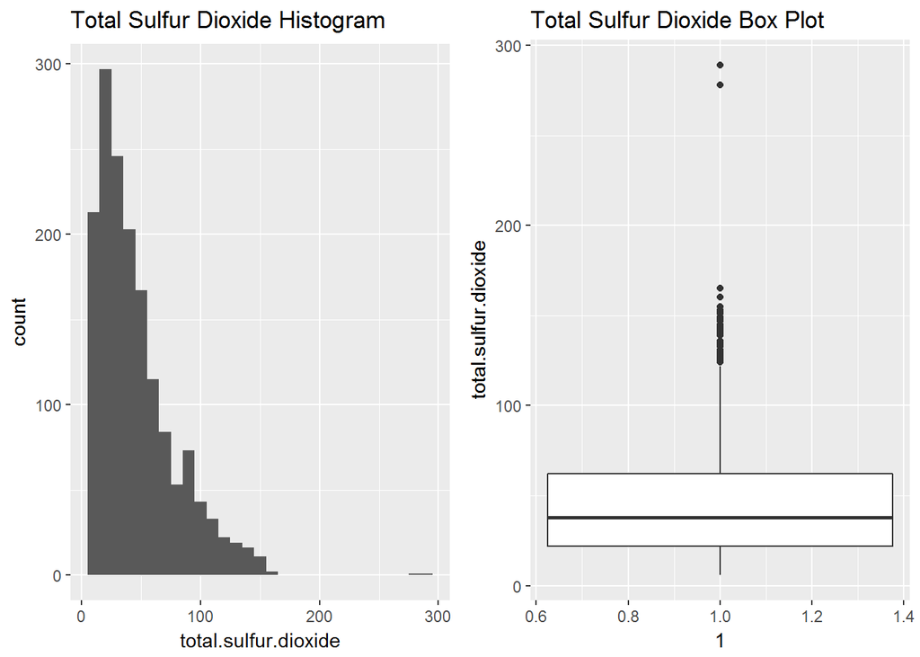

```
##
##  Pearson's product-moment correlation
##
## data:  wines$quality and log10(wines$total.sulfur.dioxide)
## t = -6.8999, df = 1597, p-value = 7.476e-12
## alternative hypothesis: true correlation is not equal to 0
## 95 percent confidence interval:
##  -0.2173510 -0.1221403
## sample estimates:
##        cor
## -0.1701427
```

[figure not shown]

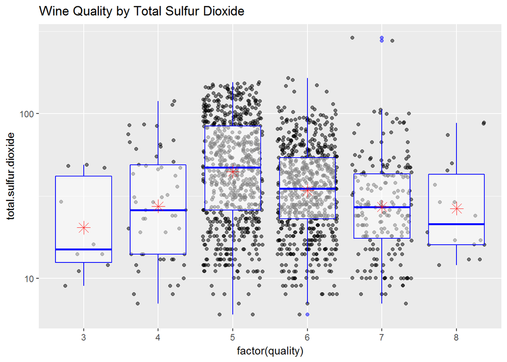

### Wine Quality vs. Density

The histogram of the density looks normal, so I won’t perform a transformation on the data. The correlation coefficient is fairly low and the scatterplot is not revealing any trends, so I will not pursue this variable further.

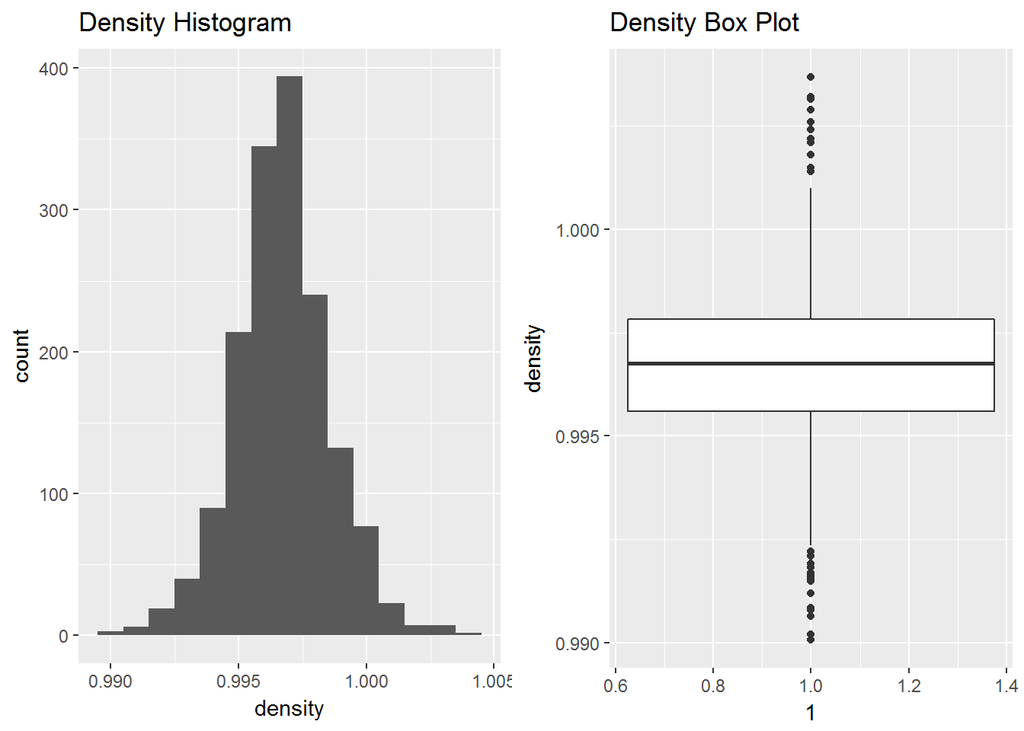

```
##
##  Pearson's product-moment correlation
##
## data:  wines$quality and wines$density
## t = -7.0997, df = 1597, p-value = 1.875e-12
## alternative hypothesis: true correlation is not equal to 0
## 95 percent confidence interval:
##  -0.2220365 -0.1269870
## sample estimates:
##        cor
## -0.1749192
```

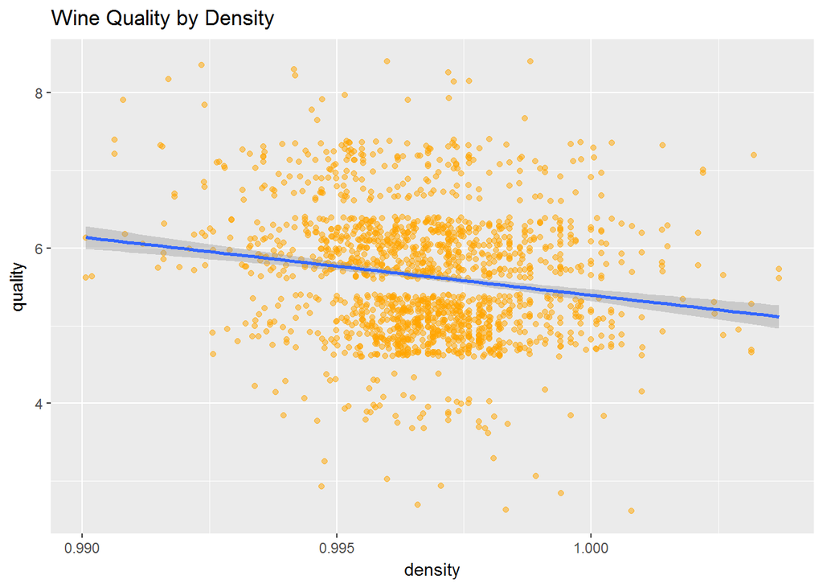

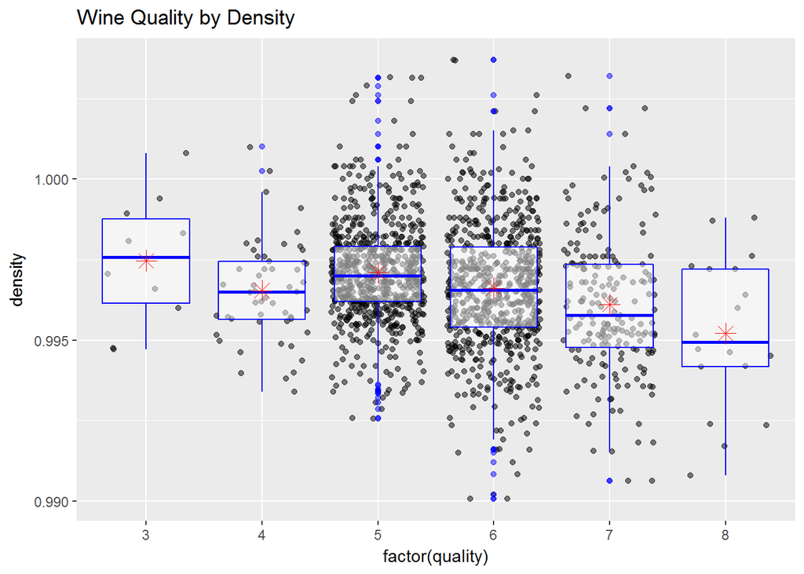

### Scatterplot of Wine Quality vs. pH

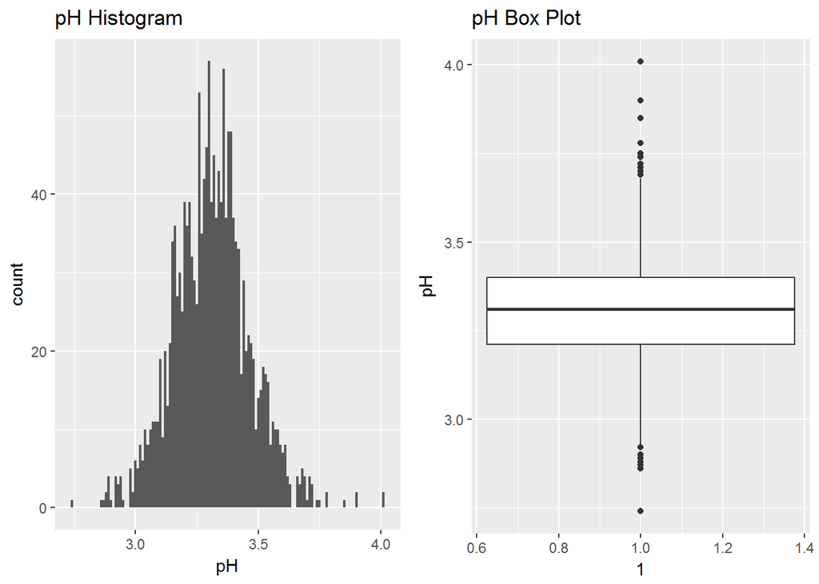

```
##
##  Pearson's product-moment correlation
##
## data:  wines$quality and log10(wines$pH)
## t = -2.3046, df = 1597, p-value = 0.02132
## alternative hypothesis: true correlation is not equal to 0
## 95 percent confidence interval:
##  -0.106294995 -0.008576923
## sample estimates:
##         cor
## -0.05757386
```

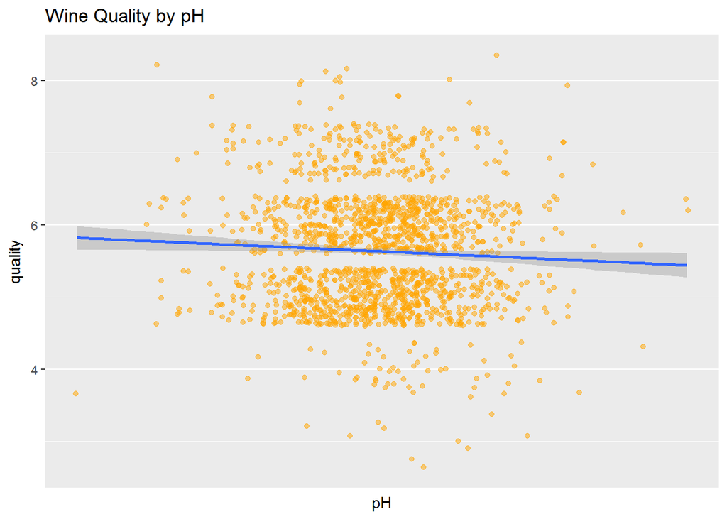

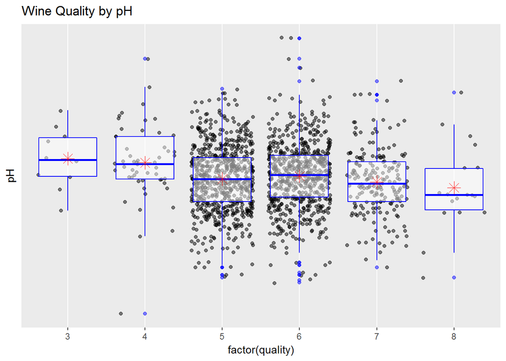

### Wine Quality vs. Sulphates

The histogram of the sulphates looks skewed, so I perform a lognormal transformation on the data. The correlation coefficient is OK and the scatterplot looks like there may be a linear trend, so I will pursue this variable further.

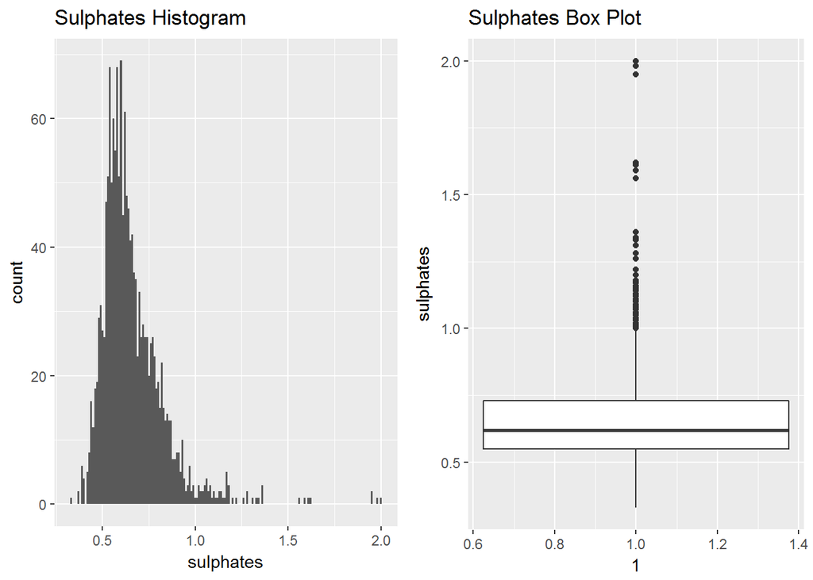

```
##
##  Pearson's product-moment correlation
##
## data:  wines$quality and log10(wines$sulphates)
## t = 12.967, df = 1597, p-value < 2.2e-16
## alternative hypothesis: true correlation is not equal to 0
## 95 percent confidence interval:
##  0.2636092 0.3523323
## sample estimates:
##       cor
## 0.3086419
```

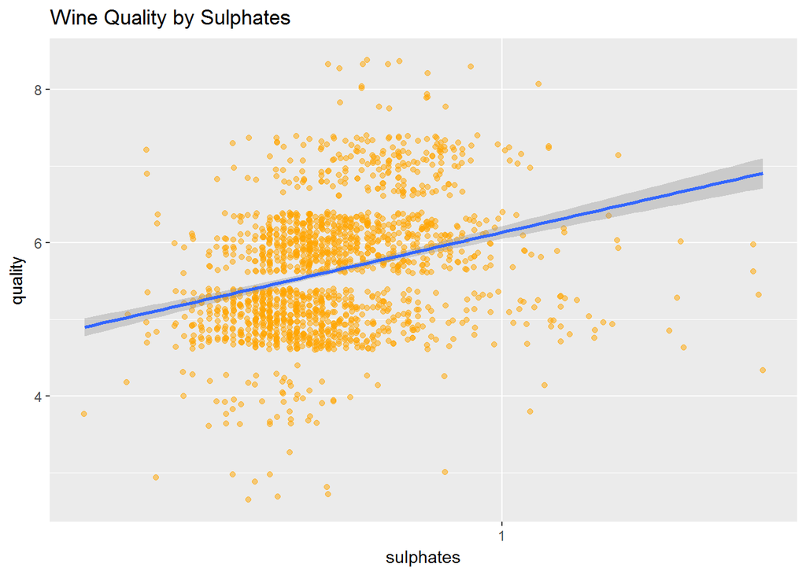

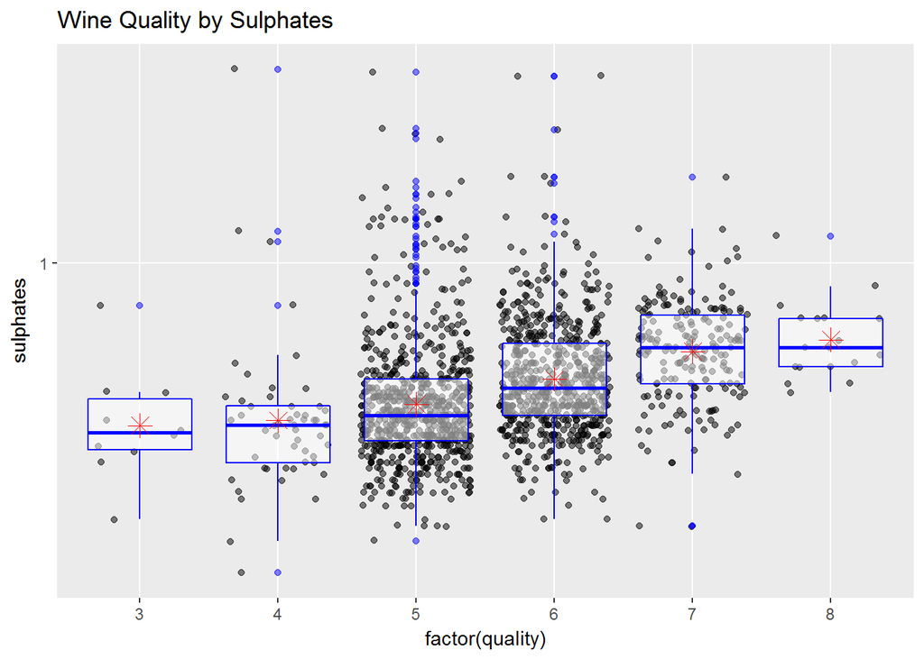